# Cysclistic 2022 Overview

## Google Data Analyst Capstone

## Introduction

Cyclistic is a bike-sharing program that features more than 5,800 bicycles and 600 docking station all across Chicago. The program was launched in 2016 and has been steady raising since then. Cyclistic sets itself apart by also offering reclining bikes, hand tricycles, and cargo bikes, making bike-share more inclusive to people with disabilities and riders who can’t use a standard two-wheeled bike. The majority of riders opt for traditional bikes; about 8% of riders use the assistive options. Cyclistic users are more likely to ride for leisure, but about 30% use them to commute to work each day.

Until now, Cyclistic’s marketing strategy relied on building general awareness and appealing to broad consumer segments. One approach that helped make these things possible was the flexibility of its pricing plans: single-ride passes, full-day passes, and annual memberships. Customers who purchase single-ride or full-day passes are referred to as casual riders. Customers who purchase annual memberships are Cyclistic members.

In order to design marketing strategies aimed at converting casual riders into anual members, the marketing analyst team needs to better understand:  
1. How do annual members and casual riders use Cyclistic bikes differently?  
2. Why would casual riders buy Cyclistic annual memberships?  
3. How can Cyclistic use digital media to influence casual riders to become members?

#### Note:

Cyclistic is a fictional company using for the purpose of this case study. The data source is provided for Google Data Analyst Professional Certificate under this [license](https://www.divvybikes.com/data-license-agreement)  
[Data source](https://divvy-tripdata.s3.amazonaws.com/index.html) Time frame between 01/01/2022 and 12/31/2022

### Load libraries

```r
library(data.table)
library(dplyr)
library(purrr)
library(ggplot2)
library(shadowtext)
library(skimr)
```

### Load and inspect data

```r
# Set directory and load the data
cyclistic_tripdata <- list.files(pattern = '*-divvy-tripdata.csv') %>%
  map_df(~fread(.))
# Summary of the data
str(cyclistic_tripdata)
```

```
## Classes 'data.table' and 'data.frame':   5667717 obs. of  13 variables:
##  $ ride_id           : chr  "C2F7DD78E82EC875" "A6CF8980A652D272" "BD0F91DFF741C66D" "CBB80ED419105406" ...
##  $ rideable_type     : chr  "electric_bike" "electric_bike" "classic_bike" "classic_bike" ...
##  $ started_at        : POSIXct, format: "2022-01-13 11:59:47" "2022-01-10 08:41:56" ...
##  $ ended_at          : POSIXct, format: "2022-01-13 12:02:44" "2022-01-10 08:46:17" ...
##  $ start_station_name: chr  "Glenwood Ave & Touhy Ave" "Glenwood Ave & Touhy Ave" "Sheffield Ave & Fullerton Ave" "Clark St & Bryn Mawr Ave" ...
##  $ start_station_id  : chr  "525" "525" "TA1306000016" "KA1504000151" ...
##  $ end_station_name  : chr  "Clark St & Touhy Ave" "Clark St & Touhy Ave" "Greenview Ave & Fullerton Ave" "Paulina St & Montrose Ave" ...
##  $ end_station_id    : chr  "RP-007" "RP-007" "TA1307000001" "TA1309000021" ...
##  $ start_lat         : num  42 42 41.9 42 41.9 ...
##  $ start_lng         : num  -87.7 -87.7 -87.7 -87.7 -87.6 ...
##  $ end_lat           : num  42 42 41.9 42 41.9 ...
##  $ end_lng           : num  -87.7 -87.7 -87.7 -87.7 -87.6 ...
##  $ member_casual     : chr  "casual" "casual" "member" "casual" ...
##  - attr(*, ".internal.selfref")=<externalptr>
```

```r
# Check for duplicated data
duplicated(cyclistic_tripdata) %>%
  summary()
```

```
##    Mode   FALSE
## logical 5667717
```

```r
head(cyclistic_tripdata)
```

| ride_id | rideable_type | started_at | ended_at | start_station_name | start_station_id | end_station_name | end_station_id | start_lat | start_lng | end_lat | end_lng | member_casual |
| --- | --- | --- | --- | --- | --- | --- | --- | --- | --- | --- | --- | --- |
| C2F7DD78E82EC875 | electric_bike | 2022-01-13 11:59:47 | 2022-01-13 12:02:44 | Glenwood Ave & Touhy Ave | 525 | Clark St & Touhy Ave | RP-007 | 42.01280 | -87.66591 | 42.01256 | -87.67437 | casual |
| A6CF8980A652D272 | electric_bike | 2022-01-10 08:41:56 | 2022-01-10 08:46:17 | Glenwood Ave & Touhy Ave | 525 | Clark St & Touhy Ave | RP-007 | 42.01276 | -87.66597 | 42.01256 | -87.67437 | casual |
| BD0F91DFF741C66D | classic_bike | 2022-01-25 04:53:40 | 2022-01-25 04:58:01 | Sheffield Ave & Fullerton Ave | TA1306000016 | Greenview Ave & Fullerton Ave | TA1307000001 | 41.92560 | -87.65371 | 41.92533 | -87.66580 | member |
| CBB80ED419105406 | classic_bike | 2022-01-04 00:18:04 | 2022-01-04 00:33:00 | Clark St & Bryn Mawr Ave | KA1504000151 | Paulina St & Montrose Ave | TA1309000021 | 41.98359 | -87.66915 | 41.96151 | -87.67139 | casual |
| DDC963BFDDA51EEA | classic_bike | 2022-01-20 01:31:10 | 2022-01-20 01:37:12 | Michigan Ave & Jackson Blvd | TA1309000002 | State St & Randolph St | TA1305000029 | 41.87785 | -87.62408 | 41.88462 | -87.62783 | member |
| A39C6F6CC0586C0B | classic_bike | 2022-01-11 18:48:09 | 2022-01-11 18:51:31 | Wood St & Chicago Ave | 637 | Honore St & Division St | TA1305000034 | 41.89563 | -87.67207 | 41.90312 | -87.67394 | member |

### Data transformation

Add a new column named `ride_length` which is calculated by subtracting the column “started_at” from the column “ended_at”

```r
# Calculate and create new column ride_length
cyclistic_tripdata <- cyclistic_tripdata %>%
  mutate(ride_length = ended_at - started_at)
```

Create a new column named `day_of_week`, and calculate the day of the week that each ride started. Note: 1=Sunday and 7=Saturday.

```r
# Create new column day_of_week
cyclistic_tripdata <- cyclistic_tripdata %>%
  mutate(day_of_week = wday(as.Date(started_at)))
```

Create a new column named `month` which shows the month when the trip was made.

```r
# Create new column month
cyclistic_tripdata <- cyclistic_tripdata %>%
  mutate(month = format(as.Date(started_at), "%m"))
```

```r
# Brief summary of the new ride_length column
skim(cyclistic_tripdata$ride_length)
```

Data summary

| Name | cyclistic_tripdata$ride_l… |
| --- | --- |
| Number of rows | 5667717 |
| Number of columns | 1 |
| _______________________ |  |
| Column type frequency: |  |
| difftime | 1 |
| ________________________ |  |
| Group variables | None |

**Variable type: difftime**

| skim_variable | n_missing | complete_rate | min | max | median | n_unique |
| --- | --- | --- | --- | --- | --- | --- |
| data | 0 | 1 | -621201 secs | 2483235 secs | 617 secs | 22312 |

#### Checking for outliers

```
## Defaulting to continuous.
```

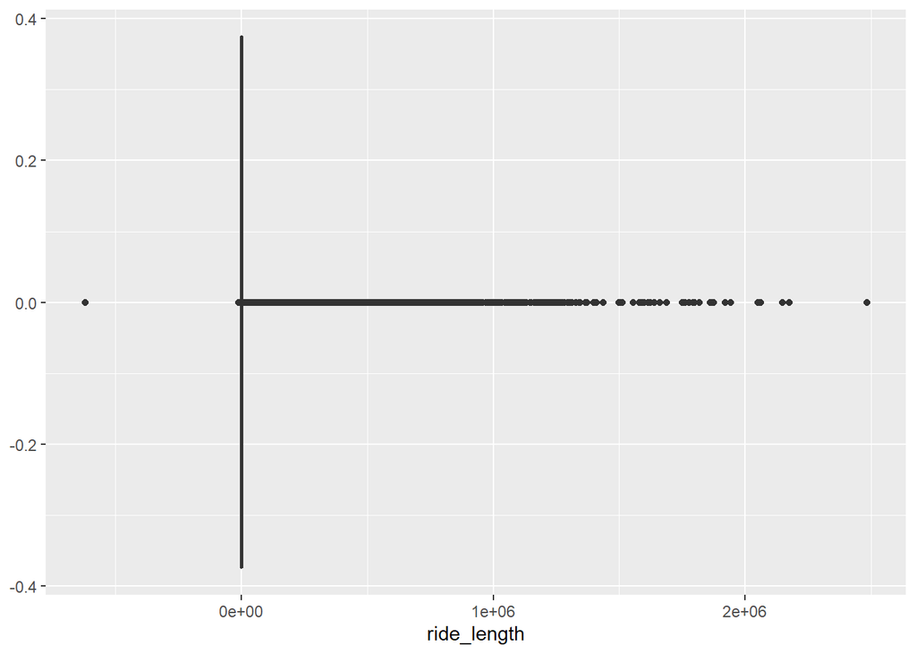

```r
# Make a box plot of `ride_length`
cyclistic_tripdata %>%
  ggplot(aes(x = ride_length)) +
  geom_boxplot()
```

The `ride_length` variable has extreme number of outliers. There are even negative values which make no sense when the length of a ride is supposed to be always positive.

#### Remove outliers

```r
# Convert ride_length which is in seconds to minutes
cyclistic_tripdata <- cyclistic_tripdata %>%
  mutate(ride_length = round(as.numeric(ride_length)/60, 1))
```

```r
# Filter out the rides which have the negative value
cyclistic_tripdata <- cyclistic_tripdata %>%
  filter(ride_length >0)
```

```r
# Calculate IQR and upper limit and lower limit
ride_length_q1 <- quantile(cyclistic_tripdata$ride_length, 0.25, na.rm = FALSE)
ride_length_q3 <- quantile(cyclistic_tripdata$ride_length, 0.75, na.rm = FALSE)
ride_length_iqr <- ride_length_q3 - ride_length_q1
lower_limit <- ride_length_q1 - ride_length_iqr * 1.5
upper_limit <- ride_length_q3 + ride_length_iqr * 1.5
```

```r
# Filter out values that are not within lower limit and upper limit
cyclistic_tripdata <- cyclistic_tripdata %>%
  filter((ride_length >= lower_limit) & (ride_length <= upper_limit))
```

```r
str(cyclistic_tripdata)
```

```
## Classes 'data.table' and 'data.frame':   5242877 obs. of  16 variables:
##  $ ride_id           : chr  "C2F7DD78E82EC875" "A6CF8980A652D272" "BD0F91DFF741C66D" "CBB80ED419105406" ...
##  $ rideable_type     : chr  "electric_bike" "electric_bike" "classic_bike" "classic_bike" ...
##  $ started_at        : POSIXct, format: "2022-01-13 11:59:47" "2022-01-10 08:41:56" ...
##  $ ended_at          : POSIXct, format: "2022-01-13 12:02:44" "2022-01-10 08:46:17" ...
##  $ start_station_name: chr  "Glenwood Ave & Touhy Ave" "Glenwood Ave & Touhy Ave" "Sheffield Ave & Fullerton Ave" "Clark St & Bryn Mawr Ave" ...
##  $ start_station_id  : chr  "525" "525" "TA1306000016" "KA1504000151" ...
##  $ end_station_name  : chr  "Clark St & Touhy Ave" "Clark St & Touhy Ave" "Greenview Ave & Fullerton Ave" "Paulina St & Montrose Ave" ...
##  $ end_station_id    : chr  "RP-007" "RP-007" "TA1307000001" "TA1309000021" ...
##  $ start_lat         : num  42 42 41.9 42 41.9 ...
##  $ start_lng         : num  -87.7 -87.7 -87.7 -87.7 -87.6 ...
##  $ end_lat           : num  42 42 41.9 42 41.9 ...
##  $ end_lng           : num  -87.7 -87.7 -87.7 -87.7 -87.6 ...
##  $ member_casual     : chr  "casual" "casual" "member" "casual" ...
##  $ ride_length       : num  3 4.3 4.3 14.9 6 3.4 16.6 12.1 25.4 7.4 ...
##  $ day_of_week       : int  5 2 3 3 5 3 1 7 2 6 ...
##  $ month             : chr  "01" "01" "01" "01" ...
##  - attr(*, ".internal.selfref")=<externalptr>
```

After removing outliers, we lost about 425 thousand records(~7.5%). We can still work perfectly fine with over 5.2 million records left.

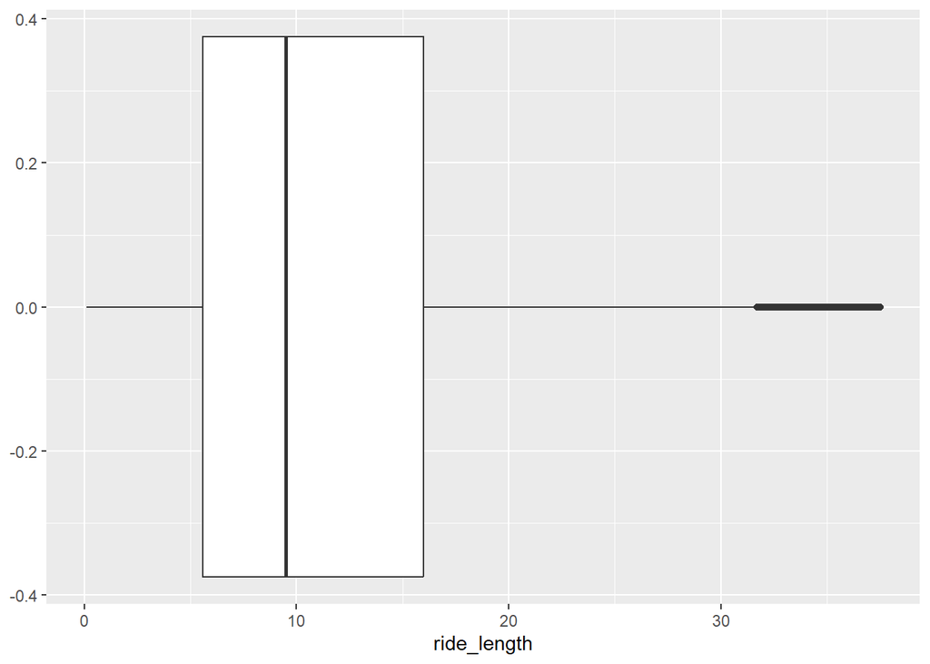

```r
# Create a box plot of the ride_length after removing outliers
cyclistic_tripdata %>%
  ggplot(aes(x= ride_length)) +
  geom_boxplot()
```

```r
# rideable_type unique values
cyclistic_tripdata$rideable_type %>%
  unique()
```

```
## [1] "electric_bike" "classic_bike"  "docked_bike"
```

There are 3 unique values in rideable_type column for three type of rental bikes, electric bikes, classic bikes, and docked bikes. However, Cyclistic only offers two types of bikes which are electric bikes and classic bikes. And all bikes are docked to stations. It seems like there was a mistake in categorizing the type of bikes. Assuming that docked_bike is the same as classic_bike, we will change all docked_bike to classic_bike.

```r
# Replace docked_bike as classic_bike
cyclistic_tripdata$rideable_type[cyclistic_tripdata$rideable_type == "docked_bike"] <- "classic_bike"
```

```r
# Check rideable_type unique values again
cyclistic_tripdata$rideable_type %>%
  unique()
```

```
## [1] "electric_bike" "classic_bike"
```

### Cyclistic in 2022

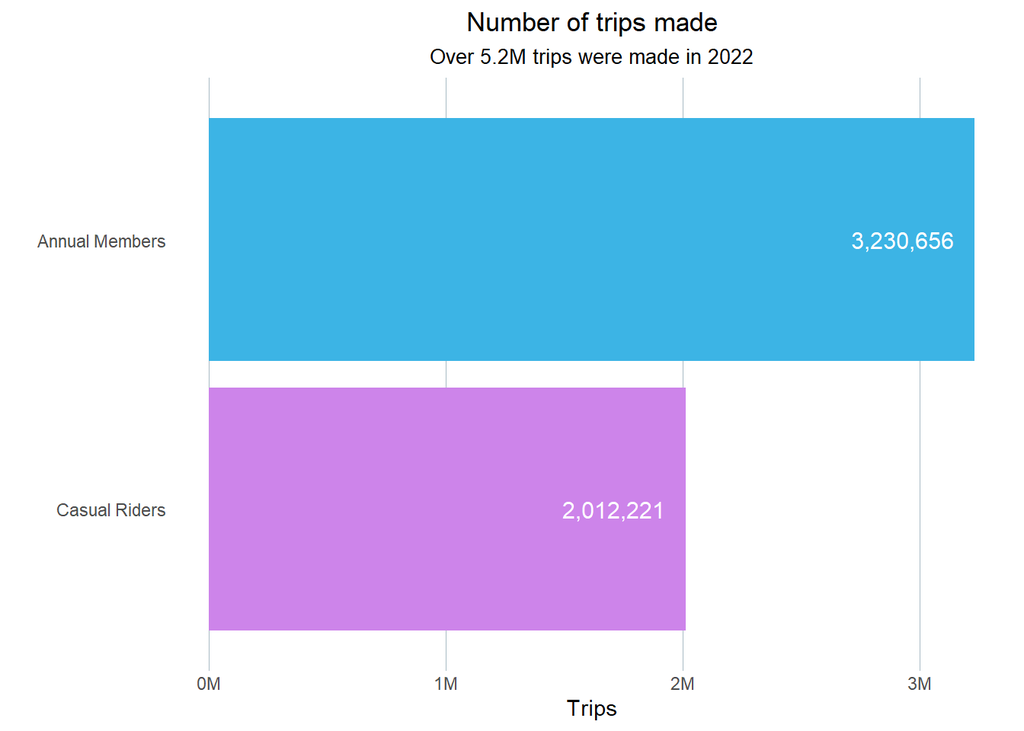

```r
# Make a bar plot for the number of trips made respect to member/non-member

ggplot(cyclistic_tripdata, aes(x= member_casual)) +
  geom_bar(fill = c("#CD84EA", "#3cb4e5")) +
  geom_text(aes(label = scales::comma(after_stat(count))), stat = "count", hjust = 1.2, color = "white", size = 4) +
  scale_x_discrete(labels = c("Casual Riders", "Annual Members")) +
  scale_y_continuous(labels = function(x) paste0(x/1e6, "M")) +
  labs(x= "", y= "Trips") +
  ggtitle("Number of trips made", subtitle = "Over 5.2M trips were made in 2022") +
  theme(plot.title = element_text(hjust = 0.5),
        plot.subtitle = element_text(hjust = 0.5, size = 10),
        panel.background = element_rect(fill= "white"),
        panel.grid.major.x = element_line(color = "#A8BAC4", linewidth = 0.3),
        axis.ticks.length = unit(0, "mm")) +
  coord_flip()
```

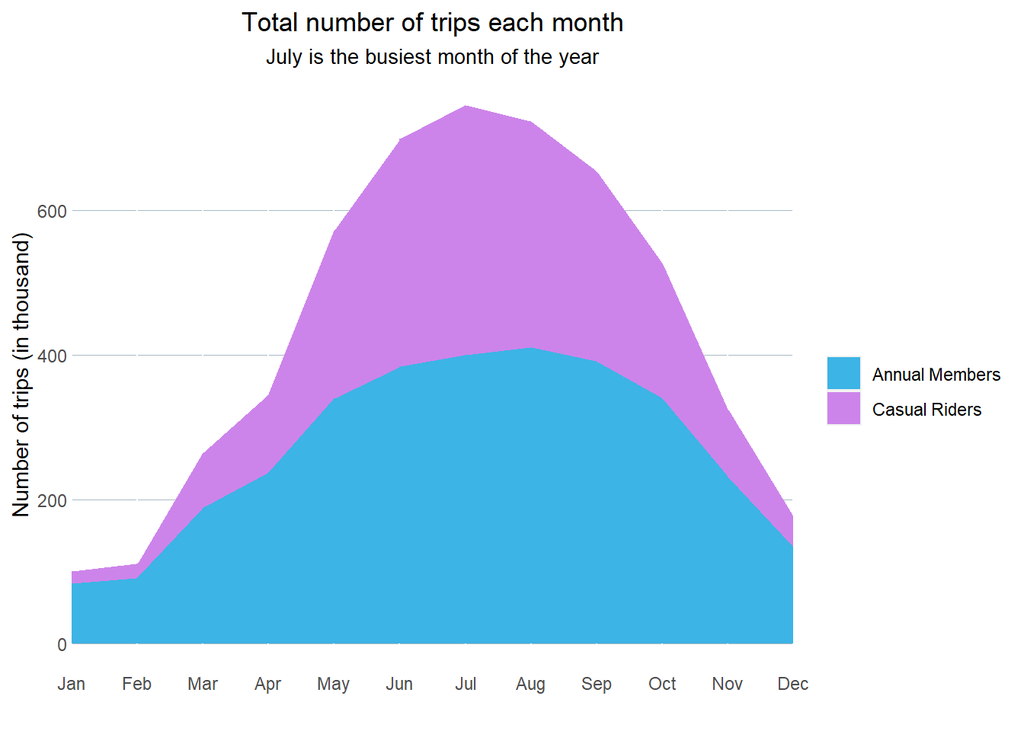

```r
# Group up the data set by the month trips were made, and count the number of trips.
cyclistic_tripdata %>%
  group_by(month, member_casual) %>%
  tally() %>%

# Make an area plot
  ggplot(aes(x= as.numeric(month), y=n, fill = member_casual)) +
  geom_area() +
  scale_x_continuous(limits = c(1,12),
                     breaks = seq(1,12),
                     labels = c("Jan", "Feb", "Mar", "Apr", "May", "Jun", "Jul", "Aug", "Sep", "Oct", "Nov", "Dec"),
                     expand = expansion(add = c(0,0))) +
  scale_y_continuous(labels = function(x) paste0(x/1000)) +
  labs(x="", y="Number of trips (in thousand)", fill = "") +
  ggtitle("Total number of trips each month",
          subtitle = "July is the busiest month of the year") +
  theme(plot.title = element_text(hjust = 0.5),
        plot.subtitle = element_text(hjust = 0.5, size = 10),
        panel.background = element_rect(fill= "white"),
        panel.grid.major.y = element_line(color = "#A8BAC4", size = 0.3),
        axis.ticks.length = unit(0,"mm")) +
  scale_fill_manual(values = c("#3cb4e5", "#CD84EA"),
                    labels = c("casual"= "Casual Riders", "member"= "Annual Members"),
                    limits = c("member", "casual"))
```

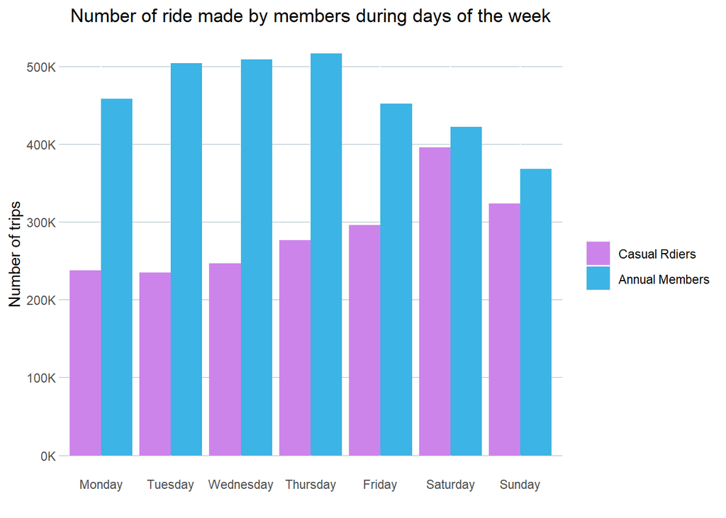

```r
# Make a side-by-side bar plot for the number of rides made by member and non-member respect to each day of the week.
ggplot(cyclistic_tripdata, aes(x= factor(day_of_week), fill = member_casual)) +
  geom_bar(position = "dodge") +
  scale_x_discrete(limits = c("2","3","4","5","6","7","1"), labels = c(
    "1"= "Sunday",
    "2"= "Monday",
    "3"= "Tuesday",
    "4"= "Wednesday",
    "5"= "Thursday",
    "6"= "Friday",
    "7"= "Saturday")) +
  scale_fill_discrete(labels = c("Casual Riders", "Annual Member")) +
  scale_y_continuous(labels = function(x) paste0(x/1000, "K")) +
  scale_fill_manual(values = c("#CD84EA", "#3cb4e5"), labels = c("member" = "Annual Members", "casual" = "Casual Rdiers")) +
  labs(x = "", y= "Number of trips", fill="") +
  ggtitle("Number of ride made by members during days of the week") +
  theme(plot.title = element_text(hjust = 0.5),
        plot.subtitle = element_text(hjust = 0.5, size = 10),
        panel.background = element_rect(fill= "white"),
        panel.grid.major.y = element_line(color = "#A8BAC4", size = 0.3),
        axis.ticks.length = unit(0,"mm"))
```

- Members made way more trips during weekdays but non-members used Cyclistic bike more in the weekend.

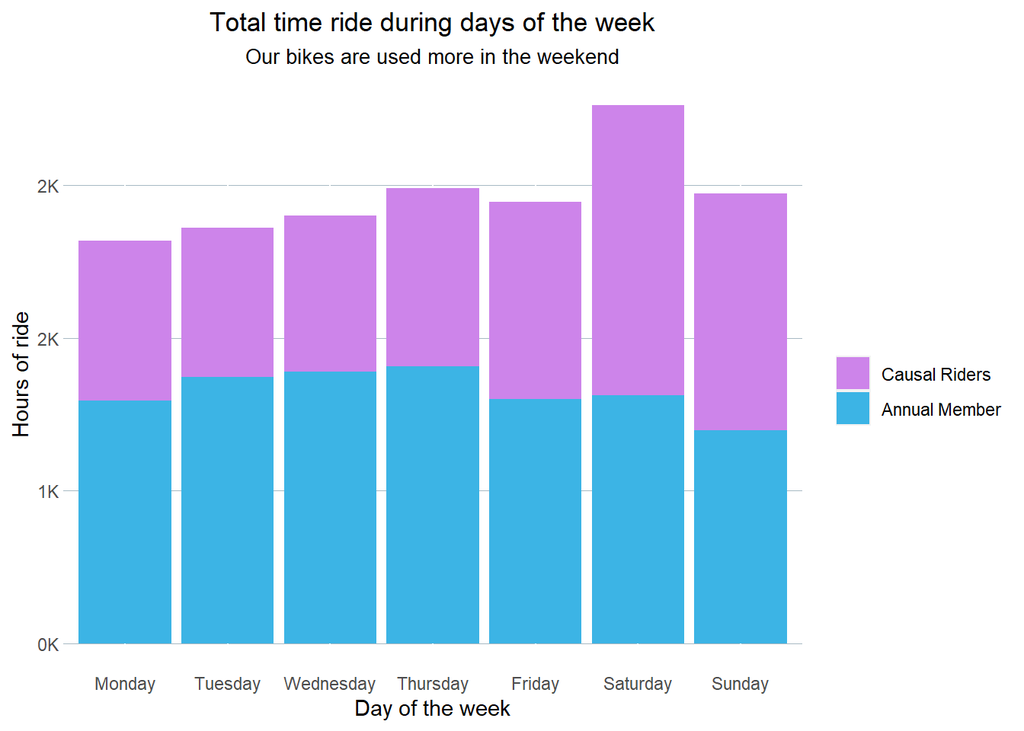

```r
# Sum up the total of the ride length was made by member and non-member for each day of the week
cyclistic_tripdata %>%
  group_by(day_of_week, member_casual) %>%
  summarise(total_ride_length = as.numeric(sum(ride_length))/60) %>%

# Make a stacked bar plot
  ggplot(aes(x=factor(day_of_week), y=total_ride_length, fill= member_casual))+
  geom_col() +
  scale_x_discrete(limits = c("2","3","4","5","6","7","1"), labels = c(
    "1"= "Sunday",
    "2"= "Monday",
    "3"= "Tuesday",
    "4"= "Wednesday",
    "5"= "Thursday",
    "6"= "Friday",
    "7"= "Saturday")) +
  scale_y_continuous(labels = function(x) paste0(round(x/1000/60), "K")) +
  scale_fill_manual(values = c("#CD84EA", "#3cb4e5"), labels = c("member" = "Annual Member", "casual" = "Causal Riders")) +
  labs(x = "Day of the week", y= "Hours of ride", fill="") +
  ggtitle("Total time ride during days of the week",
          subtitle = "Our bikes are used more in the weekend") +
  theme(plot.title = element_text(hjust = 0.5),
        plot.subtitle = element_text(hjust = 0.5, size = 10),
        panel.background = element_rect(fill= "white"),
        panel.grid.major.y = element_line(color = "#A8BAC4", size = 0.3),
        axis.ticks.length = unit(0,"mm"))
```

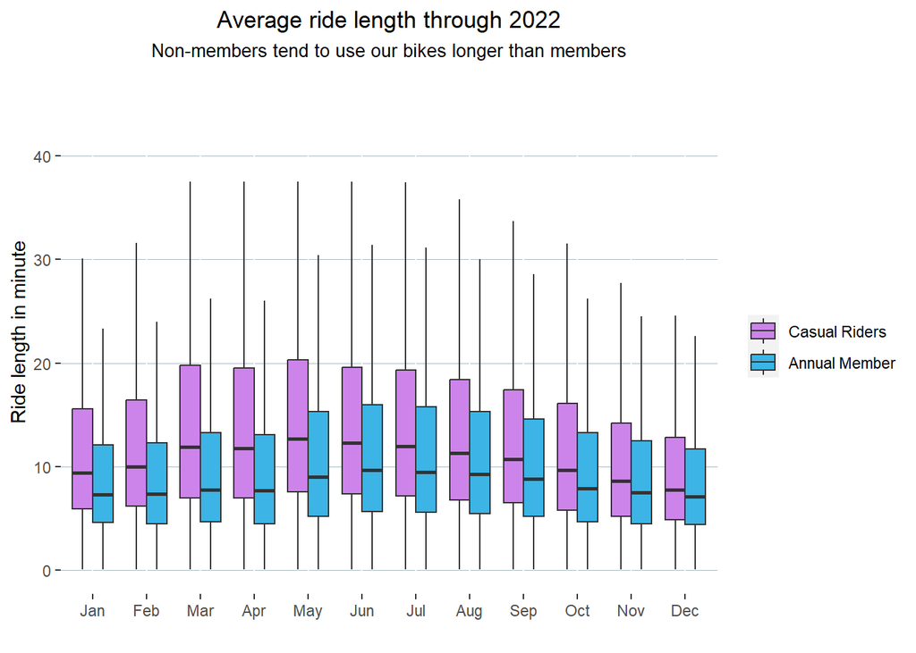

```r
# Create a boxplot to visualize the average `ride_length` for each month
cyclistic_tripdata %>%
  ggplot(aes(x= factor(month), y = ride_length)) +
  geom_boxplot(aes(fill= member_casual), position = 'dodge', outlier.shape = NA)+
  scale_x_discrete(labels = c(
                       "01" = "Jan",
                       "02" = "Feb",
                       "03" = "Mar",
                       "04" = "Apr",
                       "05" = "May",
                       "06" = "Jun",
                       "07" = "Jul",
                       "08" = "Aug",
                       "09" = "Sep",
                       "10" = "Oct",
                       "11" = "Nov",
                       "12" = "Dec"
                     )) +
  scale_y_continuous(limits = c(0,46)) +
  scale_fill_manual(values = c("#CD84EA", "#3cb4e5"),
                    labels = c("member" = "Annual Member", "casual" = "Casual Riders")
                      ) +
  labs(x='', y="Ride length in minute", fill="") +
  ggtitle("Average ride length through 2022",
          subtitle = "Non-members tend to use our bikes longer than members") +
  theme(plot.title = element_text(hjust = 0.5),
        plot.subtitle = element_text(hjust = 0.5, size = 10),
        panel.background = element_rect(fill= "white"),
        panel.grid.major.y = element_line(color = "#A8BAC4", size = 0.3))
```

- For members, they tend to use the bikes for the same amount of time throughout the year .
- Non-members tend to make longer rides than our members on average. Members used our bikes on average of under 10 minutes while non-members used our services for average of up to 13 minutes.

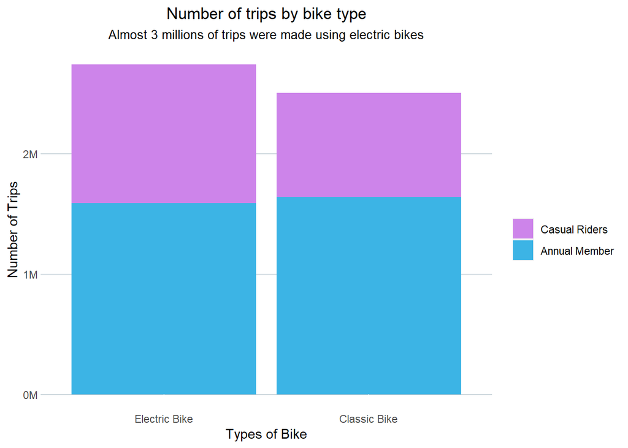

```r
ggplot(cyclistic_tripdata, aes(x= rideable_type)) +
  geom_bar(aes(fill = member_casual)) +
  scale_x_discrete(limits = c("electric_bike", "classic_bike"),
                   labels = c(
                     "electric_bike" = "Electric Bike",
                     "classic_bike" = "Classic Bike"
                   )) +
  scale_y_continuous(labels = function(x) paste0(x/1e6,"M")) +
  scale_fill_manual(values = c("#CD84EA", "#3cb4e5"),
                    labels = c("casual" = "Casual Riders", "member" = "Annual Member")) +
  labs(x="Types of Bike", y="Number of Trips", fill = "") +
  ggtitle("Number of trips by bike type",
          subtitle = "Almost 3 millions of trips were made using electric bikes") +
  theme(plot.title = element_text(hjust = 0.5),
        plot.subtitle = element_text(hjust = 0.5, size = 10),
        panel.background = element_rect(fill= "white"),
        panel.grid.major.y = element_line(color = "#A8BAC4", size = 0.3),
        axis.ticks.length = unit(0,"mm"))
```

- The most popular type of bike was electric bike. Amost 3 million trips were made using electric bikes.
- Non-members tend to use electric bikes more than classic bikes. While members used electric bikes and classic bikes to make the same number amount of trips.

[figure not shown]

```r
# Create a new data frame with 10 stations with the most number of rides were made.
top_10_busiest_station <- cyclistic_tripdata %>%
  group_by(start_station_id, start_station_name) %>%
  tally() %>%
  arrange(desc(n)) %>%
  filter(start_station_id != "") %>%
  head(10)

# Create a bar chart for the count for the 10 busiest stations
ggplot(top_10_busiest_station, aes(x= reorder(start_station_name, n), y= n)) +
  geom_col(fill = "#3cb4e5") +
  coord_flip() +
  labs(y = "Number of trips", x='') +
  ggtitle("Top 10 busiest station",
          subtitle = "Over 75 thounsand trips started from Streeter Dr & Grand Ave") +
  theme(plot.title = element_text(hjust = 0.5),
        plot.subtitle = element_text(hjust = 0.5, size = 10),
        panel.background = element_rect(fill= "white"),
        panel.grid.major.x = element_line(color = "#A8BAC4", size = 0.3),
        axis.ticks.length = unit(0,"mm"))
```

### Recomendations

_ Since casual riders tend to make longer trips than annual members, Cyclistic’s marketing department can run advertisements to highlight the cost benefit of the annual membership. At the current price of annual membership, casual riders only need to make 1 trip per week to break even on classic bike when most casual rides are between 10-12 minutes.  
_ Since casual riders use electric bikes more than classic bike, the annual membership will save them a big amount when they use electric bike. $1 unlock + $0.42/minute for casual ride vs free unlock + $0.17/minute for membership.  
_ Bikes are also a environment friendly method of transportation, advertisements to encourage more people to ride bikes to save our environment will bring in more users and becoming a membership is solid message showing that we care deeply to our environment.